# What You Need To Win A League Of Legends Game

Kris Li

## Introduction

The goal of this survey is to build a statistical learning model that can predict the **Win/Lose** outcome of a player’s League of Legends game based on the game statistics of all this player.

### Why This Topic?

League of Legends is a team-based strategy game where two teams of five powerful champions face off to destroy the others’ base. League of Legends is the largest MOBA game title currently. With over 150 million registered players, any topic about the game could be widely spread in the gaming field easily. On the internet, there is a huge market of making gaming tutorial. And the hard core e-sport title League of Legends is one of the biggest part of this market. However, although their are many technical tutorials about how to play a character in the game better, there are not many resource about the analytically data side of the game. Players may want to learn from the objective fact instead of subjective explanations of the game.

## Data Preparing

First thing first, we load all libraries needed for data processing, visualization, and modeling.

```r
library(ggplot2)
library(ggpubr)
library(corrplot)
library(dplyr)
library(readr)
library(tidymodels)
library(ISLR)
library(ISLR2)
library(tidyverse)
library(glmnet)
library(rpart.plot)
library(janitor)
library(randomForest)
library(vip)
library(xgboost)
library(ranger)
library(Hmisc)
library(kknn)
library(kernlab)
library(nnet)
library(caret)
tidymodels_prefer()
set.seed(1203)
```

### Data Loading

Because the data source provides raw and roughly processed data which has ‘translated’ the metadata from data crawling to readable data, we chose the roughly processed data as our base data before implementing more data processing. Since the roughly processed data are in multiple .csv files, we first combine them.

We successfully acquired a single large dataset(284196 obs. of 63 variables). We can proceed to data cleaning.

### Data Cleaning and Analysis

- Clean variable names with clean_names() to make calling variables easier by gets rid of the unreadable characters.
- Remove `gameId`, `summonerName`, `puuid` with select() because they are just random strings that are not of our interests.
- Remove `unrealKills` because I have no idea what it is.

```r
# omit rows with empty values
LOL_original = na.omit(LOL_original)

LOL <- LOL_original %>%
  clean_names() %>%
  select(-game_id, -summoner_name, -puuid, -unreal_kills)
```

- Check the distribution of outcome:

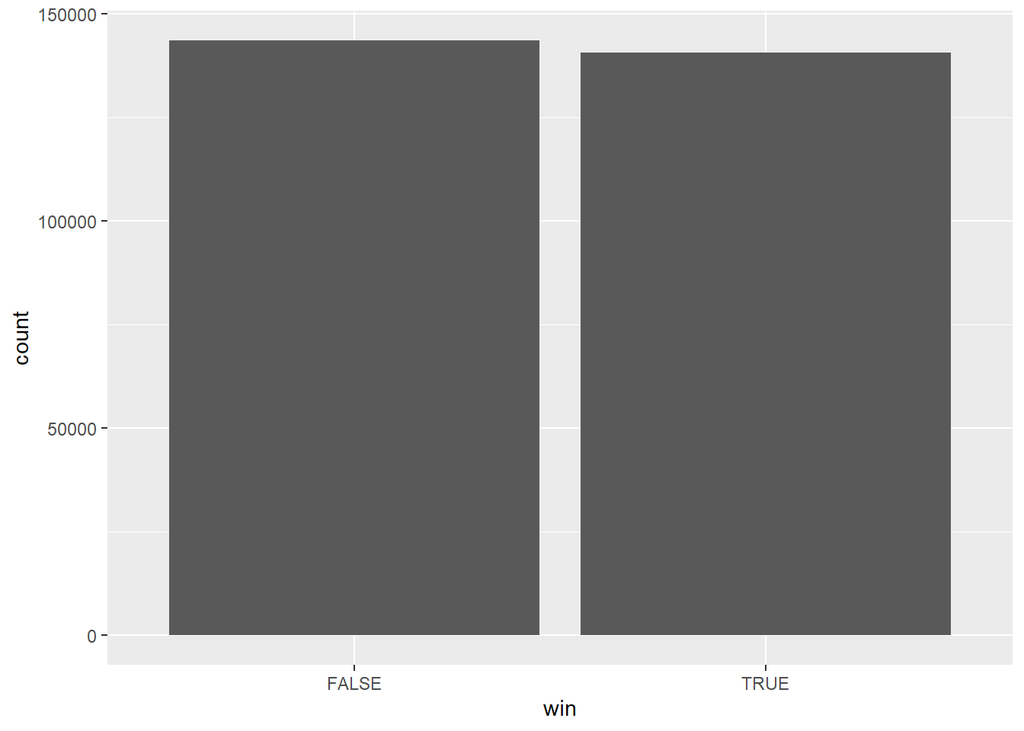

```r
LOL %>%
  ggplot(aes(x = win)) +
  geom_bar()
```

The win rate of all observations is slightly smaller than 1/2. The difference is small but a stratified sampling may be more accurate when splitting.

- Check variable types:

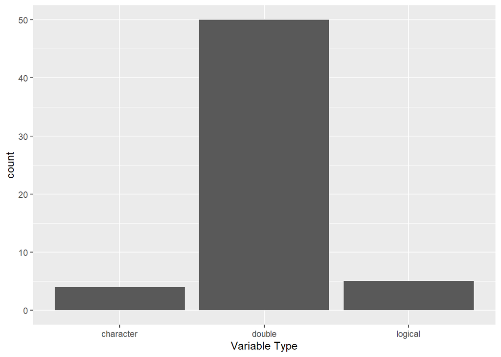

```r
var_type <- as.data.frame(sapply(LOL, typeof))
p <- ggplot(data=var_type, aes(x=sapply(LOL, typeof))) +
     geom_bar(stat = "count") +
     xlab('Variable Type')
p
```

We need to transform factors into numeric, for further analysis such as correlation analysis. But let’s first check numerical variables’ distributions.

- Check distribution of all numerical variables:

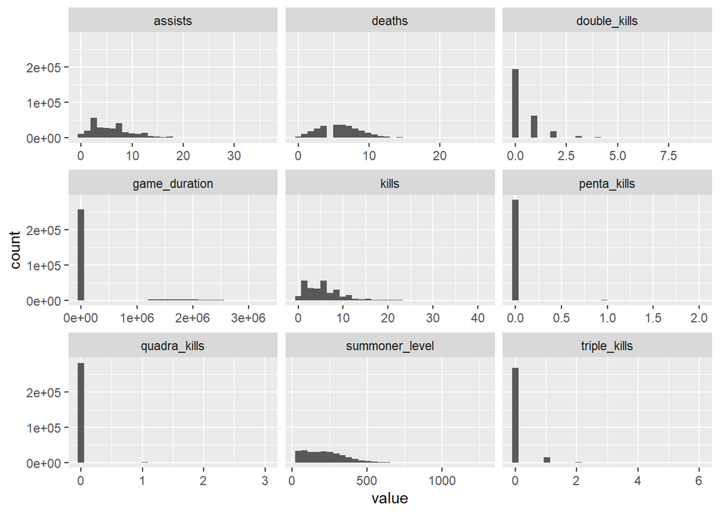

```r
LOL_num <- LOL %>% select_if(is.numeric)
hist1 <- ggplot(gather(LOL_num[,c(1:9)]), aes(value)) +
  geom_histogram(bins = 30) +
  facet_wrap(~key, scales = 'free_x')
hist2 <- ggplot(gather(LOL_num[,c(10:18)]), aes(value)) +
  geom_histogram(bins = 30) +
  facet_wrap(~key, scales = 'free_x')
hist3 <- ggplot(gather(LOL_num[,c(19:27)]), aes(value)) +
  geom_histogram(bins = 30) +
  facet_wrap(~key, scales = 'free_x')
hist4 <- ggplot(gather(LOL_num[,c(28:36)]), aes(value)) +
  geom_histogram(bins = 30) +
  facet_wrap(~key, scales = 'free_x')
hist5 <- ggplot(gather(LOL_num[,c(37:45)]), aes(value)) +
  geom_histogram(bins = 30) +
  facet_wrap(~key, scales = 'free_x')
hist6 <- ggplot(gather(LOL_num[,c(46:50)]), aes(value)) +
  geom_histogram(bins = 30) +
  facet_wrap(~key, scales = 'free_x')

hist1
```

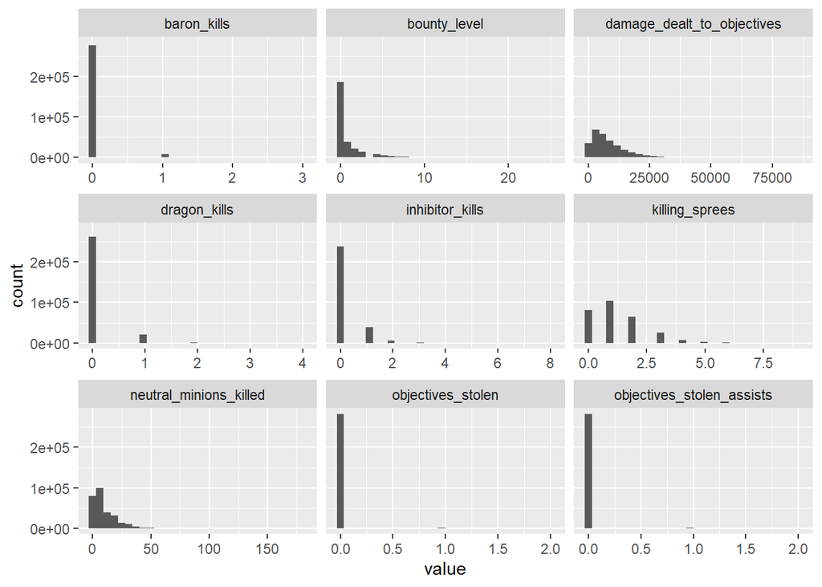

```r
hist2
```

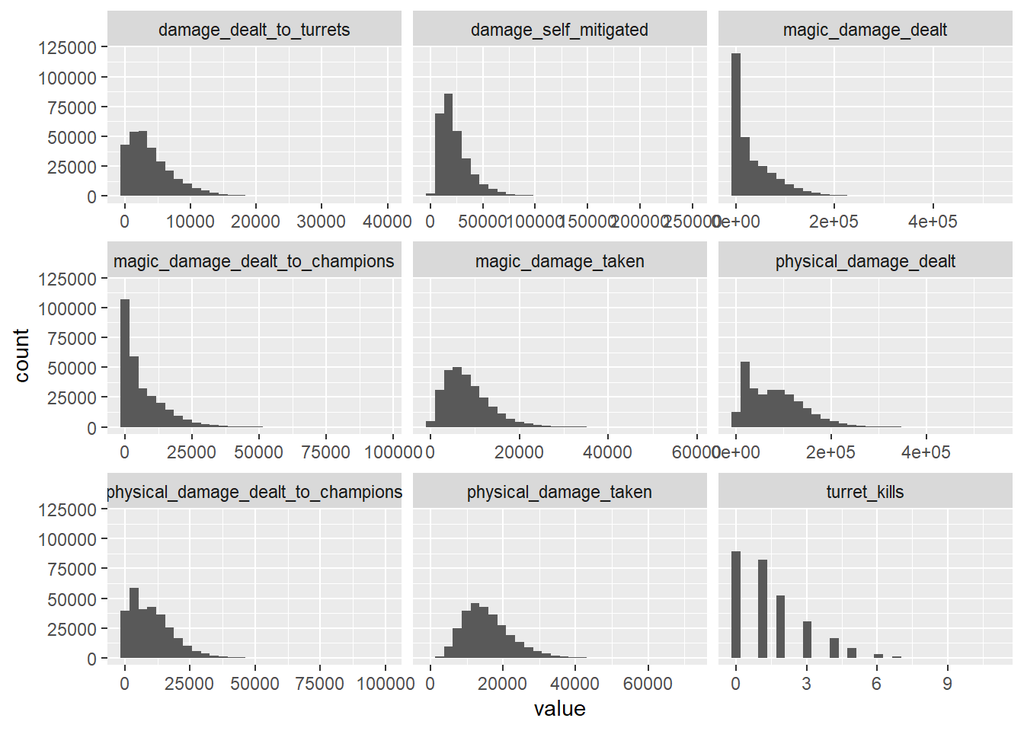

```r
hist3
```

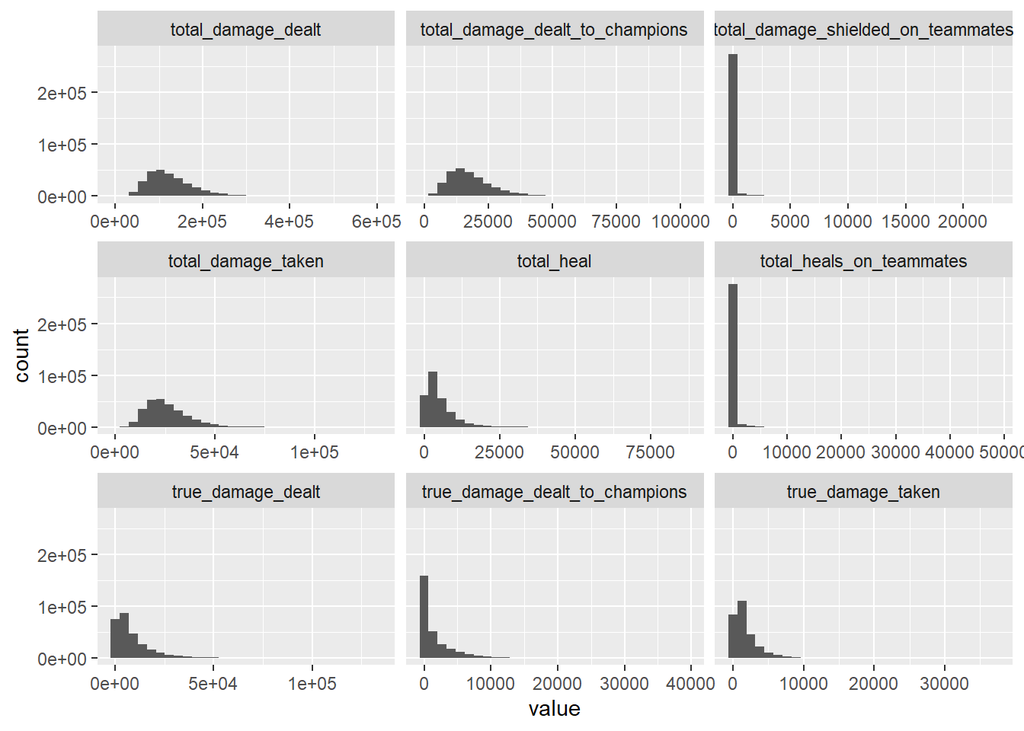

```r
hist4
```

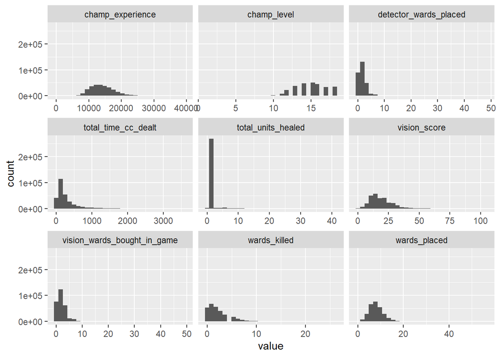

```r
hist5
```

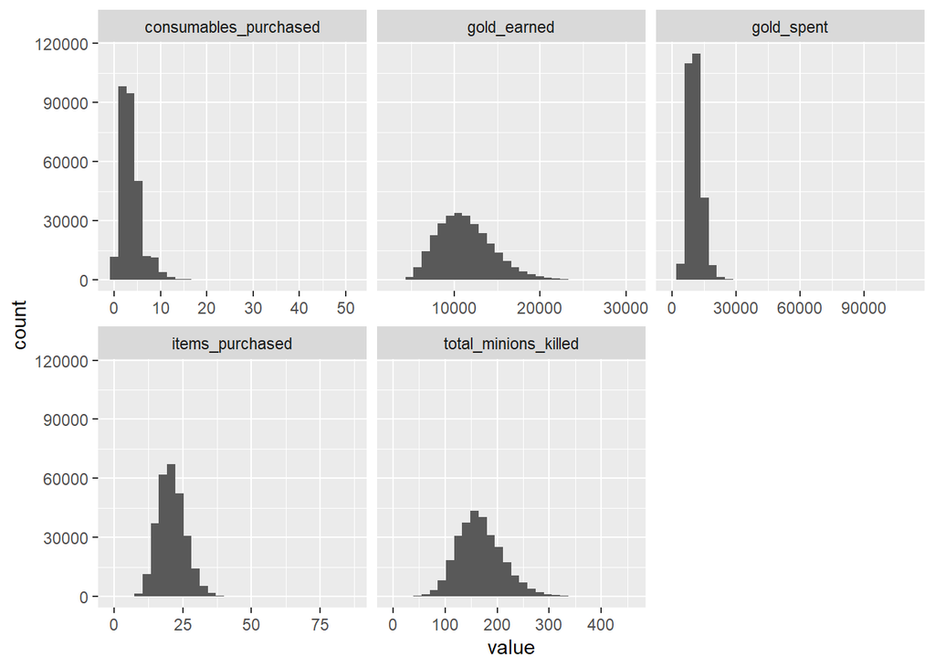

```r
hist6
```

We see that most of them are right skewed. Since the amount of skewness is acceptable, we will try variable transformations(Log-transformation since they are right-skewed) in model building.

We can also notice that `game_duration` has a bunch of outliers that doesn’t make sense, such as a 2000000 second game which convert to hours is 555. Since our research focus on the average game stats and we have more than enough data, we don’t need to check if these outliers make sense in their individual cases. We can simply get rid of them. But since`game_duration` is expected to be a useful predictor, we can’t remove this variable but can only remove the rows that don’t make sense.

According to https://us.millenium.gg/news/24746.html, the longest game in the history of League of Legends is 237 min and 02 seconds. So we omit rows with values larger than that.

```r
dim(LOL)
```

```
## [1] 284196     59
```

```r
LOL <- LOL[LOL$game_duration <= 14222, ]
dim(LOL)
```

```
## [1] 257525     59
```

We got rid of 284196 - 257525 = 26671 useless row of data!

Also, we can see that `lane` is uniformly distributed, `role`, `individual_position`, `penta_kills`, `quadra_kills`, `triple_kills`, `objective_stolen`, `objective_stolen_assists` are unimodal discretely distributed. These variables don’t have enough variations so they won’t contribute to our study. Let’s remove them.

```r
LOL <- LOL %>%
  select(-lane, -role, -individual_position, -penta_kills, -quadra_kills, -triple_kills, -objectives_stolen, -objectives_stolen_assists)
dim(LOL)
```

```
## [1] 257525     51
```

We now have 51 variables in the dataset.

- Mutate variable types for correlation plot:

```r
LOL_mutate <- LOL %>%
  mutate_if(is.character, as.factor) %>%
  mutate_if(is.logical, as.factor) %>%
  mutate_if(is.factor, as.numeric)
```

- Compute correlations with corr_simple():

*corr_simple() is from https://towardsdatascience.com/how-to-create-a-correlation-matrix-with-too-many-variables-309cc0c0a57, I altered it to be able to set up a range for the correlation coefficient.*

Let’s check the correlation table and plot.

We will look at the pairs that have correlation coefficients >= 0.85 to identify redundant variables.

```r
corr_simple(LOL_mutate ,0.85,1)
```

```
##                       Var1                               Var2      Freq
## 2340           champ_level                   champ_experience 0.9576327
## 2496           gold_earned                         gold_spent 0.9526055
## 2028 detector_wards_placed        vision_wards_bought_in_game 0.9347981
## 1144    magic_damage_dealt    magic_damage_dealt_to_champions 0.9088309
## 2443      champ_experience                        gold_earned 0.9063996
## 2425    total_damage_dealt                        gold_earned 0.8865881
## 2374    total_damage_dealt               total_minions_killed 0.8810250
## 2442           champ_level                        gold_earned 0.8731039
## 2494      champ_experience                         gold_spent 0.8695700
## 2323    total_damage_dealt                   champ_experience 0.8689596
## 1557 physical_damage_taken                 total_damage_taken 0.8599593
## 988           turret_kills            damage_dealt_to_turrets 0.8576342
## 2476    total_damage_dealt                         gold_spent 0.8559218
## 1300 physical_damage_dealt physical_damage_dealt_to_champions 0.8520072
## 2296         game_duration                   champ_experience 0.8515476
```

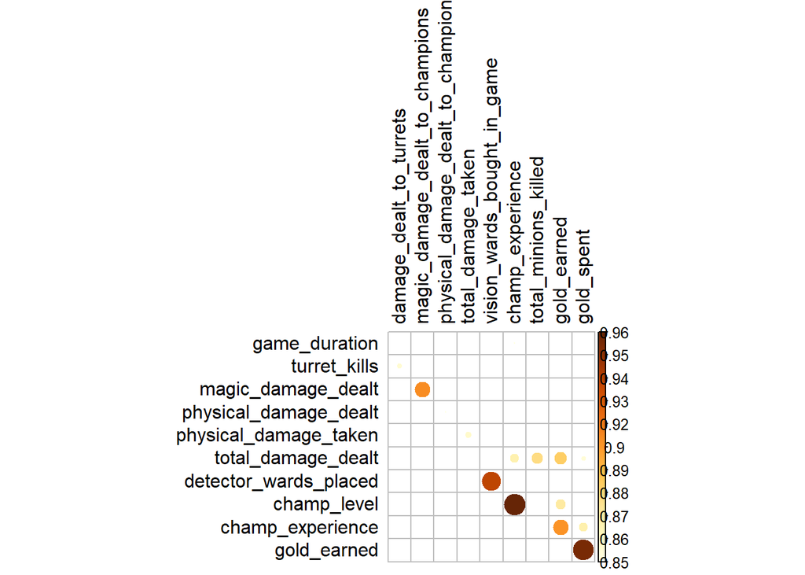

We see that `champ_level vs. champ_experience`, `gold_earned vs. gold_spent`, `detector_wards_placed vs. vision_wards_bought_in_game` and `turret_kills vs. damage_dealt_to_turrets` are redundant because champions level up by gaining a certain amount of experience point; players always spend all their gold in order to be more powerful; players need to buy detector ward before using them; players need to dealt damage to turret to take them down. So we remove `champ_experience`, `gold_earned`, `turret_kills`, and `vision_wards_bought_in_game`.

```r
LOL <- LOL %>%
  select(-champ_experience, -gold_earned, -vision_wards_bought_in_game, -turret_kills)
LOL_mutate <- LOL_mutate %>%
  select(-champ_experience, -gold_earned, -vision_wards_bought_in_game, -turret_kills)
corr_simple(LOL_mutate,0.85,1)
```

```
##                       Var1                               Var2      Freq
## 1008    magic_damage_dealt    magic_damage_dealt_to_champions 0.9088309
## 2048    total_damage_dealt               total_minions_killed 0.8810250
## 1389 physical_damage_taken                 total_damage_taken 0.8599593
## 2095    total_damage_dealt                         gold_spent 0.8559218
## 1152 physical_damage_dealt physical_damage_dealt_to_champions 0.8520072
```

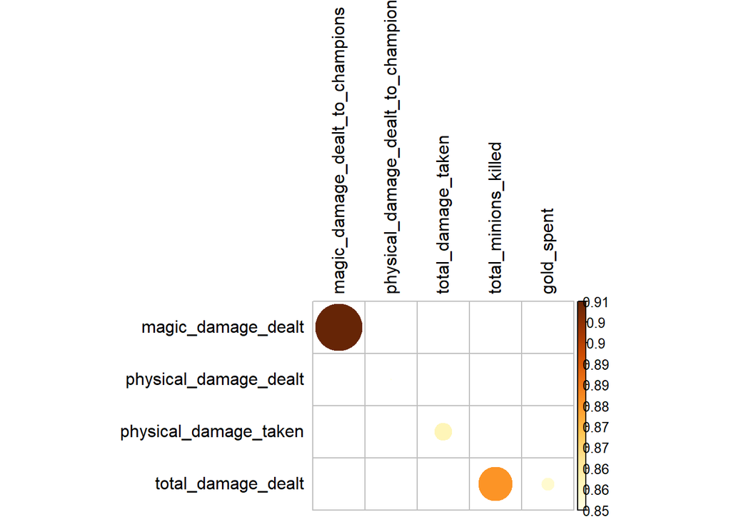

Now the strongly correlated pairs are all logical but not redundant.

Repeat these steps, the finalized reduced dataset is:

```r
LOL <- LOL %>%
  select(win, bounty_level, kills, assists, champ_level, double_kills, total_damage_dealt_to_champions, vision_score, damage_dealt_to_objectives, inhibitor_kills, killing_sprees, neutral_minions_killed, gold_spent) %>%
  mutate_if(is.logical, as.factor)
LOL
```

```
## # A tibble: 257,525 x 13
##    win   bounty_level kills assists champ_level double_kills total_damage_dealt~
##    <fct>        <dbl> <dbl>   <dbl>       <dbl>        <dbl>               <dbl>
##  1 FALSE            0     1       1          12            0               12495
##  2 TRUE             3    11      15          15            1               31874
##  3 FALSE            0     5       8          16            0               18428
##  4 TRUE             2     9      15          18            0               30897
##  5 FALSE            0     7       4          14            1               25694
##  6 TRUE             0     9       8          15            1               26145
##  7 TRUE             2     4       1          14            0                6436
##  8 TRUE             2    10       9          16            2               22271
##  9 FALSE            0    12       6          16            1               36775
## 10 FALSE            0     4       0          14            0               10410
## # ... with 257,515 more rows, and 6 more variables: vision_score <dbl>,
## #   damage_dealt_to_objectives <dbl>, inhibitor_kills <dbl>,
## #   killing_sprees <dbl>, neutral_minions_killed <dbl>, gold_spent <dbl>
```

We have finished data cleaning! A Code book of the current dataset `LOL_codebook.txt` is attached in the folder.

### Correlation Analysis

This is a correlation plot of all numerical variables.

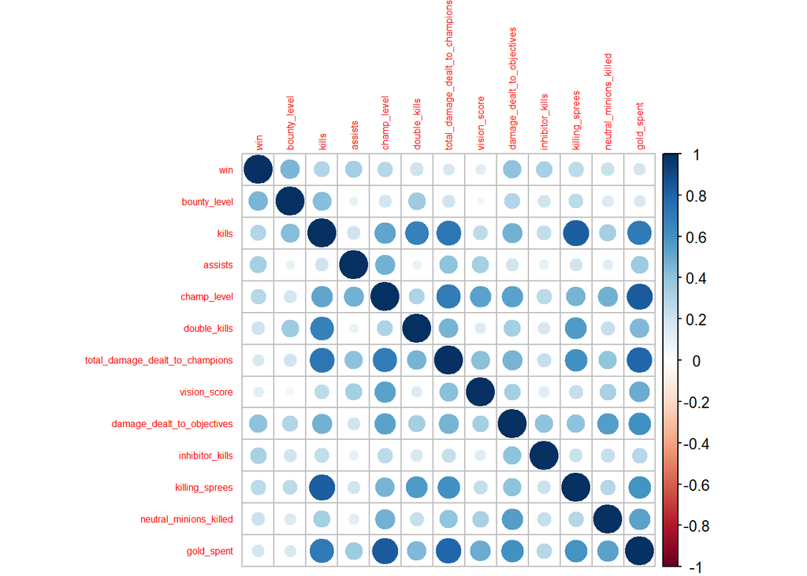

```r
LOL_mutate <- LOL %>%
  mutate_if(is.character, as.factor) %>%
  mutate_if(is.factor, as.numeric)
corrplot(cor(LOL_mutate, use = "complete.obs"),tl.cex=0.5)
```

Then, let’s look at the correlation coefficients of the pairs `win` vs. all predictors.

```r
M <- cor(LOL_mutate[-1], LOL_mutate$win)
M[order(M[,1],decreasing=TRUE),]
```

```
##                    bounty_level      damage_dealt_to_objectives
##                       0.4514595                       0.4089794
##                         assists                 inhibitor_kills
##                       0.3363699                       0.3217111
##                           kills                     champ_level
##                       0.2905714                       0.2855635
##                  killing_sprees          neutral_minions_killed
##                       0.2665436                       0.2167981
##                    double_kills                      gold_spent
##                       0.2079535                       0.1801769
## total_damage_dealt_to_champions                    vision_score
##                       0.1603829                       0.1262199
```

The largest correlation coefficient is 0.4514595, and most of them are much smaller than this.

## Model Building

### Data Spliting

Since there are 257525 observations, a 80/20 split is definitely valid with respect to the size of the testing set. As mentioned before when checking the response distribution, we will use stratified sampling by the outcome variable `win`.

```r
# LOL = LOL[sample(nrow(LOL),2500),]
LOL_split <- LOL %>%
  initial_split(prop = 0.8, strata = "win")

LOL_train <- training(LOL_split)
LOL_test <- testing(LOL_split)

dim(LOL_train)[1]
```

```
## [1] 206019
```

```r
dim(LOL_test)[1]
```

```
## [1] 51506
```

```r
LOL_train$win <- as.factor(LOL_train$win)
```

There are 206019 observation in the training set `LOL_train` and 51506 observation in the testing set `LOL_test`.

### Construct the recipe

Set up a recipe to predict `win` with all predictors. Dummy-code all nominal predictors; Center and scale all predictors.

```r
LOL_recipe <- recipe(win ~ ., data = LOL_train) %>%
  step_dummy(all_nominal_predictors()) %>%
  step_normalize(all_predictors())
```

### K-fold Cross Validation

```r
LOL_folds <- vfold_cv(LOL_train, strata = win, v = 20)
```

### Model fitting

Since this is a binary classification question, and according to https://ruslanmv.com/blog/The-best-binary-Machine-Learning-Model, I decided to fit the following models:

- Logistic Regression
- Decision Tree
- Random Forest
- Elastic Net
- Boosted Tree
- Support Vector Machine (Polynomial)

#### Logistic Regression

```r
log_reg <- logistic_reg() %>%
  set_engine("glm") %>%
  set_mode("classification")

log_wkflow <- workflow() %>%
  add_recipe(LOL_recipe) %>%
  add_model(log_reg)

log_fit <- fit_resamples(log_wkflow, LOL_folds)

save(log_fit, log_wkflow, file = "rdas/log_fit.rda")
```

#### Decision Tree (Tuned)

```r
dt_spec <- decision_tree() %>%
  set_engine("rpart") %>%
  set_mode("classification")

dt_wkflow <- workflow() %>%
  add_model(dt_spec %>% set_args(cost_complexity = tune())) %>%
  add_recipe(LOL_recipe)

param_grid <- grid_regular(cost_complexity(range = c(-5, -1)), levels = 10)

dt_tune <- tune_grid(
  dt_wkflow,
  resamples = LOL_folds,
  grid = param_grid,
  metrics = metric_set(roc_auc)
)

save(dt_tune, dt_wkflow, file = "rdas/Decision Tree.rda")
```

#### Random Forest (Tuned)

```r
rf_spec <- rand_forest() %>%
  set_engine("ranger", importance = "impurity") %>%
  set_mode("classification")

rf_wf <- workflow() %>%
  add_model(rf_spec %>% set_args(mtry = tune(), trees = tune(), min_n = tune())) %>%
  add_recipe(LOL_recipe)

rf_tune <-
  rf_wf %>%
  tune_grid(
    resamples = LOL_folds,
    grid = expand.grid(
      mtry = c(1:12),
      trees = c(20, 50, 60, 80),
      min_n = c(2, 5, 15, 20)),
      metrics = metric_set(roc_auc)
  )

save(rf_tune, rf_wf, file = "rdas/Random Forest.rda")
```

#### Elastic Net

```r
elastic_net_spec <- multinom_reg(penalty = tune(),
                                 mixture = tune()) %>%
  set_mode("classification") %>%
  set_engine("glmnet")

en_workflow <- workflow() %>%
  add_recipe(LOL_recipe) %>%
  add_model(elastic_net_spec)

en_grid <- grid_regular(penalty(range = c(-5, 5)),
                        mixture(range = c(0, 1)), levels = 10)

en_tune <- tune_grid(
  en_workflow,
  resamples = LOL_folds,
  grid = en_grid
)

save(en_tune, en_workflow, file = "rdas/Elastic Net.rda")
```

#### Boosted Tree

```r
bt_spec <- boost_tree(mode = "classification",
                       min_n = tune(),
                       mtry = tune(),
                       learn_rate = tune()) %>%
  set_engine("xgboost")

bt_workflow <- workflow() %>%
  add_model(bt_spec) %>%
  add_recipe(LOL_recipe)

bt_params <- parameters(bt_spec) %>%
  update(mtry = mtry(range= c(1, 12)),
         learn_rate = learn_rate(range = c(-5, 0.2))
  )

bt_grid <- grid_regular(bt_params, levels = 2)

bt_tune <- bt_workflow %>%
  tune_grid(
    resamples = LOL_folds,
    grid = bt_grid
    )

save(bt_tune, bt_workflow, file = "rdas/Boosted Tree.rda")
```

#### SVM(poly)

```r
svm_spec <- svm_poly(degree = 1, cost = 1/4) %>%
  set_engine("kernlab") %>%
  set_mode("classification")

svm_wf <- workflow() %>%
  add_model(svm_spec) %>%
  add_recipe(LOL_recipe)

svm_grid <- grid_regular(cost(range = c(0, 5)),
                         degree(range = c(2,5)), levels = 10)

svm_tune <- tune_grid(
  svm_wf,
  resamples = LOL_folds,
  grid = svm_grid
)

save(svm_fit, svm_wf, file = "rdas/SVM.rda")
```

### Model selection and performance:

Let’s compare model performance by accuracy and roc_auc.

```r
# Load models
load(file = "rdas/log_fit.rda")
load(file = "rdas/Decision Tree.rda")
load(file = "rdas/Random Forest.rda")
load(file = "rdas/Elastic Net.rda")
load(file = "rdas/Boosted Tree.rda")
load(file = "rdas/SVM.rda")
```

Best roc_auc of each model:

```r
# Logistic Regression
log_fit_metrics <- collect_metrics(log_fit) %>%
  arrange(desc(mean)) %>% head(1)
# Pruned decision tree
dt_tune_metrics <- collect_metrics(dt_tune) %>%
  arrange(desc(mean)) %>% head(1)
# Random Forest
rf_tune_metrics <- collect_metrics(rf_tune) %>%
  arrange(desc(mean)) %>% head(1)
# Elastic Net
en_tune_metrics <- collect_metrics(en_tune) %>%
  arrange(desc(mean)) %>% head(1)
# Boosted Tree
bt_tune_metrics <- collect_metrics(bt_tune) %>%
  arrange(desc(mean)) %>% head(1)
# SVM
svm_fit_metrics <- collect_metrics(svm_fit) %>%
  arrange(desc(mean)) %>% head(1)


# Combined
results <- bind_rows(log_fit_metrics, dt_tune_metrics, rf_tune_metrics, en_tune_metrics, bt_tune_metrics, svm_fit_metrics) %>%
  tibble() %>%
  mutate(model = c("Logistic", "Decision Tree", "Random Forest", "Elastic Net", "Boosted Tree", "SVM"))
results %>%
  select(model, mean, std_err) %>%
  arrange(desc(mean))
```

```
## # A tibble: 6 x 3
##   model          mean std_err
##   <chr>         <dbl>   <dbl>
## 1 Random Forest 0.913 0.00719
## 2 SVM           0.910 0.00767
## 3 Elastic Net   0.909 0.00388
## 4 Logistic      0.908 0.00385
## 5 Boosted Tree  0.893 0.00479
## 6 Decision Tree 0.870 0.00426
```

We can see that `Random Forest` with parameters `mtry=2, trees=60, min_n=15`, has the highest mean of roc_auc.

`SVM` has the second largest mean of roc_auc but has a higher standard error.

However, I decided to choose the `elastic net` model with `penalty = 0.001668101, mixture = 1` here because its mean of roc_auc is very close to the one of `random forest` model (about 1 standard error away), but it has a much a lower standard error.

#### Elastic Net Analysis and Final Fitting:

Let’s visualize the tuning of the elastic net.

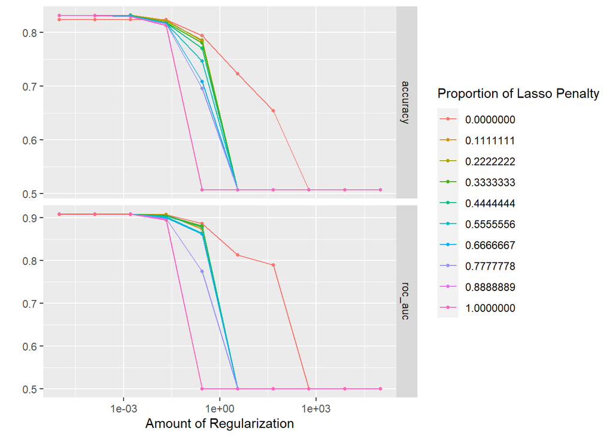

```r
autoplot(en_tune)
```

```r
rf_tune_metrics <- collect_metrics(rf_tune) %>%
  arrange(desc(mean))
```

The plot shows that smaller values of amount of regularization and smaller values of proportion of lasso penalty tend to result in higher ROC-AUC and accuracy values..

Let’s look at the performance of the tuned `elastic net` on the whole training set:

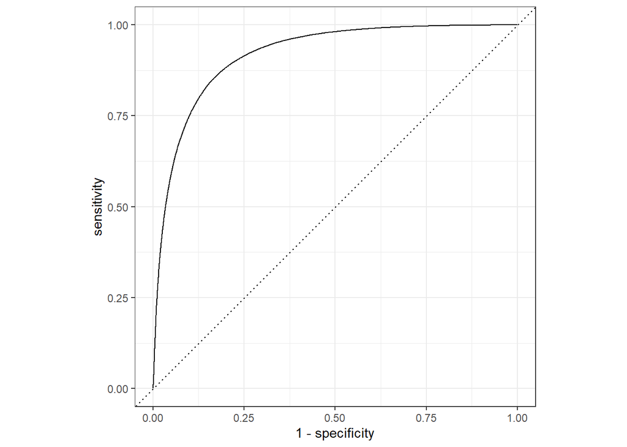

```r
best_en <- select_best(en_tune, metric = "roc_auc")
en_wf <- finalize_workflow(en_workflow, best_en)
en_fit <- fit(en_wf, data = LOL_train)
predicted_data <- augment(en_fit, new_data = LOL_train) %>%
  select(win, starts_with(".pred"))
predicted_data %>% roc_curve(win, .pred_FALSE) %>% autoplot()
```

```r
predicted_data %>% roc_auc(win, .pred_FALSE)
```

```
## # A tibble: 1 x 3
##   .metric .estimator .estimate
##   <chr>   <chr>          <dbl>
## 1 roc_auc binary         0.917
```

The overall roc_auc on the training set is 0.9171857, a strong value.

We can now fit it to the `testing set`.

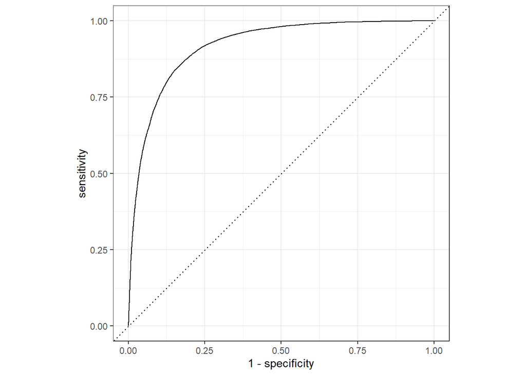

```r
predicted_data_test <- augment(en_fit, new_data = LOL_test) %>%
  select(win, starts_with(".pred"))
predicted_data_test %>% roc_curve(win, .pred_FALSE) %>% autoplot()
```

```r
predicted_data_test %>% roc_auc(win, .pred_FALSE)
```

```
## # A tibble: 1 x 3
##   .metric .estimator .estimate
##   <chr>   <chr>          <dbl>
## 1 roc_auc binary         0.918
```

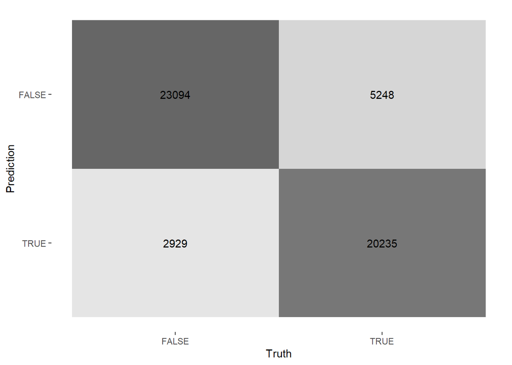

```r
predicted_data_test %>%
  conf_mat(truth = win, estimate = .pred_class) %>%
  autoplot(type = "heatmap")
```

```r
win <- as.numeric(predicted_data$win)
pred.win <- as.numeric(predicted_data$.pred_class)
(sum(win==pred.win)) / length(pred.win)
```

```
## [1] 0.8408739
```

The overall roc_auc is 0.9175225, even higher than it was in the training set. The difference of the two are very small, so the cause of this is probably that we have a big data set, so the stratified randomized training and testing sets show almost identical response to model fitting.

## Conclusion

This model is possible to be generated to a much larger dataset because it has a large number of observations which included a large amount of the player base of League of Legends.

#### Applications

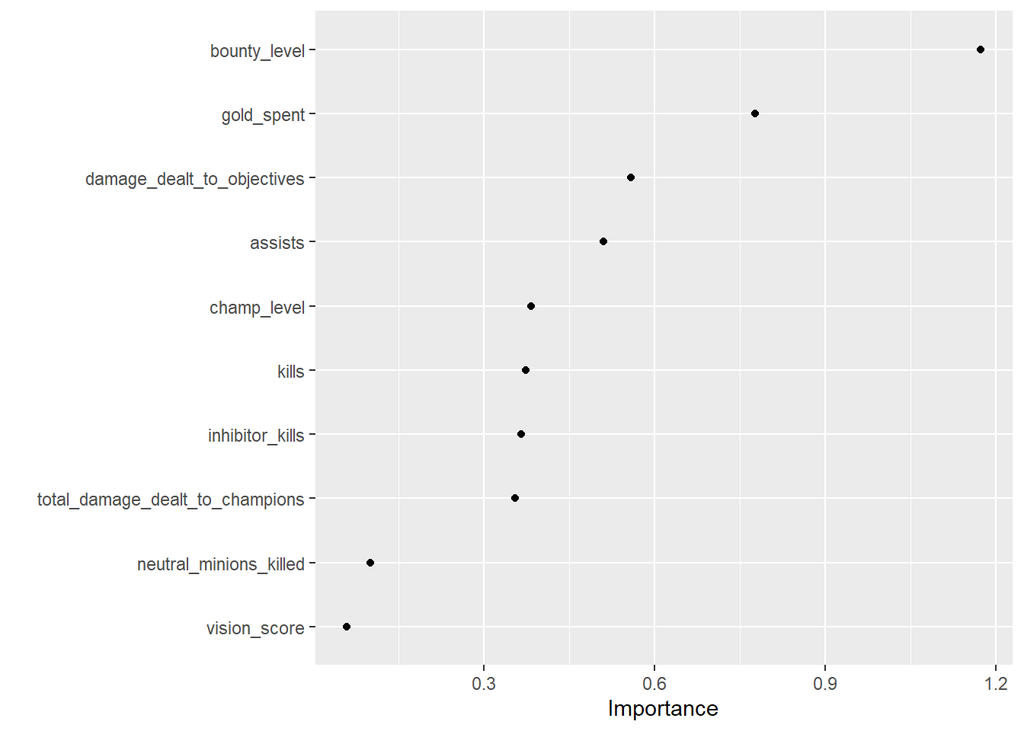

```r
en_wf %>%
  fit(data = LOL_test) %>%
  pull_workflow_fit() %>%
  vip(geom = "point")
```

We can use the variable importance plot to observe that `vision_score` and `neutral_minions_killed` are not very important in predicting the outcome of the game with this model. This would be an interesting argument to be published because these two variables are commonly know as the factors that distinguish between a good player and a bad player.

#### Future improvements

I have possibly made some human error in variable selection in EDA. We can try to include more variables or change some existed variables for model fitting.